# Customizing models and MCMCs

NIMBLE 2024 TWS Workshop

NIMBLE Development Team

October 2024

# Agenda for this module

1. Introduction to Markov chain Monte Carlo (MCMC).
2. Building a model and running MCMC in NIMBLE.
3. Understanding how to efficiently program a model.
4. How to configure samplers in NIMBLE.

# Bayes’ law (conditional probability)

In a hierarchical model, we typically have:

- params: top-level parameters, e.g. coefficients and std. deviations.
- states: random effects or latent states.
- data

We are interested in the joint posterior distribution of the unknown variables (parameters and states)

$$[\mbox{params, states | data}] = \frac{[\mbox{data | states,
params}][\mbox{states | params}] [\mbox{params}]}{[\mbox{data}]}$$

- $[\cdot]$ indicates probability density or mass.
- Denominator is hard to calculate but it is a constant (generally requires a high dimensional integration).
- More often we want to know the marginal posterior distribution of each param or state, which is the integral of joint posterior distribution over all other states and params.
- Model calculations refer to the numerator, $[\mbox{data, states, params}]$.

# Why Markov chain Monte Carlo

- MCMC is a method that avoids integration by sampling proportional to the joint posterior distribution.
- Markov chain means that each new sample will only depend on the previous sample, and the chain will have properties that should result in generating samples from the posterior distribution.
- Monte Carlo means that the Markov chain is constructed with random sampling.
- For efficiency, nimble only does calculations that are dependent on the param or state being changed for each MCMC iteration. This is done through the graphical relationships between data, states, and params.
- Output from MCMC is a matrix of samples for each param and state drawn from the posterior distribution. Taken together, it represents the joint posterior distribution. Taken one param at a time it represents the marginal posterior distribution.

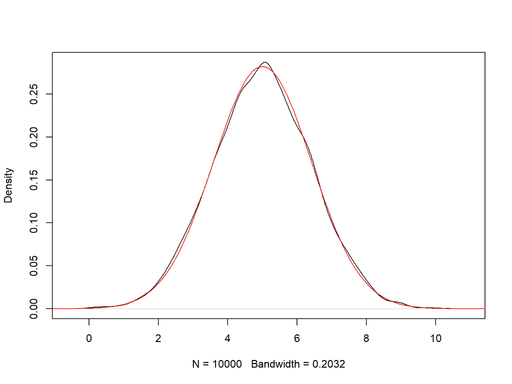

```r
samples <- MASS::mvrnorm(10000, mu = c(5, 3, 10), Sigma = rbind(c(2, 1, 0.5), c(1, 3, 0.75), c(0.5, 0.75, 1.75)))

x <- seq(-3, 20, by = 0.1)
plot(density(samples[,1]), main = "")
lines(x, dnorm(x, mean = 5, sd = sqrt(2)), col = 'red')
```

# Gibbs (conjugate) samplers

- Possible when we can write the full conditional posterior distribution, $[\theta_1 | \theta_F, Y]$, analytically.
- This only works for particular (*conjugate*) prior-posterior combinations.
- Despite sounding simple, there is some computational cost.
- Both JAGS and NIMBLE use conjugate samplers by default when available.

Example, $y \sim Poisson(\lambda)$ and $\lambda \sim \text{gamma}(1,1)$.

```r
y <- rpois(100, 3)
post.lambda <- rgamma(10000, 1 + sum(y), 1+100) ## 10000 Gibbs samples for lambda.

demoCode <- nimbleCode({
for(i in 1:n) y[i] ~ dpois(lambda)
  lambda ~ dgamma(shape = 1, rate = 1)
})

demoModel <- nimbleModel(demoCode, data = list(y=y),
    constants = list(n = length(y)), inits = list(lambda = 1))
```

```
## Defining model
```

```
## Building model
```

```
## Setting data and initial values
```

```
## Running calculate on model
##   [Note] Any error reports that follow may simply reflect missing values in model variables.
```

```
## Checking model sizes and dimensions
```

```r
mcmcConf <- configureMCMC(demoModel)
```

```
## ===== Monitors =====
## thin = 1: lambda
## ===== Samplers =====
## conjugate sampler (1)
##   - lambda
```

```r
mcmcConf$printSamplers()
```

```
## [1] conjugate_dgamma_dpois_identity sampler: lambda
```

```r
mcmc <- buildMCMC(mcmcConf)
cdemoModel <- compileNimble(demoModel)
```

```
## Compiling
##   [Note] This may take a minute.
##   [Note] Use 'showCompilerOutput = TRUE' to see C++ compilation details.
```

```r
cmcmc <- compileNimble(mcmc)
```

```
## Compiling
##   [Note] This may take a minute.
##   [Note] Use 'showCompilerOutput = TRUE' to see C++ compilation details.
```

```r
cmcmc$run(10000)
```

```
## |-------------|-------------|-------------|-------------|
## |-------------------------------------------------------|
```

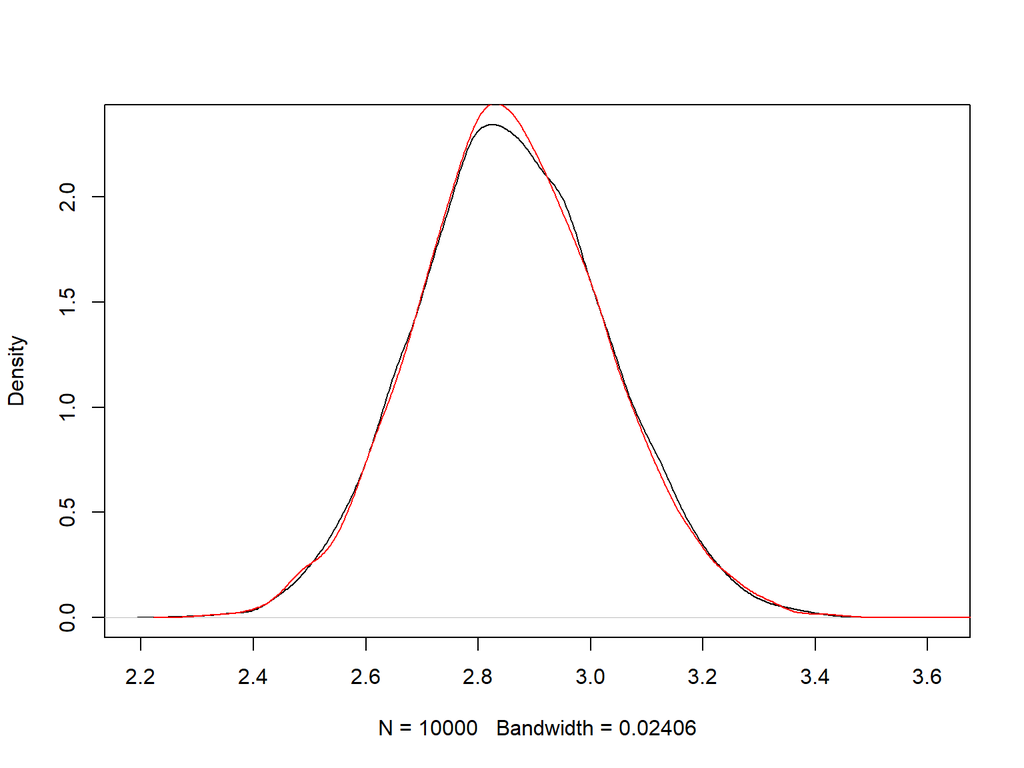

```r
samples <- as.matrix(cmcmc$mvSamples)

plot(density(post.lambda), main ="")
lines(density(samples), col = 'red')
```

# Adaptive Random-walk Metropolis-Hastings samplers

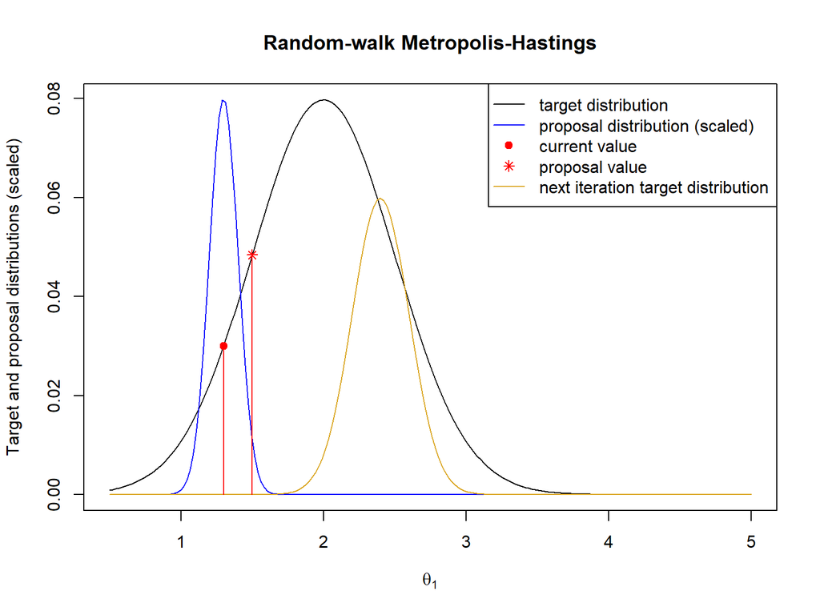

- Current value of the parameter is $\theta_1$.
- Propose a new value (red asterisk) $\theta_1' \sim N(\theta, \nu)$ (blue distribution). This is centered on the current value, so we call it a “random walk”.
- How to accept or reject $\theta_1'$?
  - Calculate ratio of $[Y, (\theta_1', \theta_F)] / [Y, (\theta_1, \theta_F)]$ (using only needed factors).
  - If the ratio is $\gt 1$, accept $\theta'$.
  - Otherwise that ratio is the “acceptance probability”.
  - Draw a uniform random variate to decide whether to accept or reject.
  - Rejection means $\theta_1^{(k+1)} = \theta_1^{(k)}$
- Computational cost is either
  - two evaluations of $[Y, (\theta_1', \theta_F)]$ (only the parts that depend on $\theta_1$), or
  - one evaluation of $[Y, (\theta_1', \theta_F)]$ (ditto) and some copying to save previous values.
- How to choose $\nu$?
  - By “adaptation”. The algorithm increases or decreases $\nu$ to achieve theoretically derived optimal acceptance rate.
- Remember that the target distribution may change on the next iteration because $\theta_F$ may have been updated.
- Generalizes to multivariate (block) sampling.
- This method is computationally cheap but may or may not mix well.

# How NIMBLE’s MCMC workflow works


# (Repeat AHM example setup if necessary)

```r
Section10p4_code <- nimbleCode({
  # Priors
  mean.p ~ dunif(0, 1)         # Detection intercept on prob. scale
  alpha0 <- logit(mean.p)      # Detection intercept
  alpha1 ~ dunif(-20, 20)      # Detection slope on wind
  mean.psi ~ dunif(0, 1)       # Occupancy intercept on prob. scale
  beta0 <- logit(mean.psi)     # Occupancy intercept
  beta1 ~ dunif(-20, 20)       # Occupancy slope on vegHt

  # Likelihood
  for (i in 1:M) {
    # True state model for the partially observed true state
    z[i] ~ dbern(psi[i])      # True occupancy z at site i
    logit(psi[i]) <- beta0 + beta1 * vegHt[i]
    for (j in 1:J) {
      # Observation model for the actual observations
      y[i,j] ~ dbern(p.eff[i,j])    # Detection-nondetection at i and j
      p.eff[i,j] <- z[i] * p[i,j]   # 'straw man' for WinBUGS
      logit(p[i,j]) <- alpha0 + alpha1 * wind[i,j]
    }
  }
  # Derived quantities are removed.
}
)

if(!exists("DO_PLOT"))
  DO_PLOT <- FALSE
# Choose sample sizes and prepare obs. data array y
set.seed(1)                   # So we all get same data set
M <- 100                      # Number of sites
J <- 3                        # Number of presence/absence measurements
y <- matrix(NA, nrow = M, ncol = J) # to contain the obs. data

# Create a covariate called vegHt
vegHt <- sort(runif(M, -1, 1)) # sort for graphical convenience

# Choose parameter values for occupancy model and compute occupancy
beta0 <- 0                    # Logit-scale intercept
beta1 <- 3                    # Logit-scale slope for vegHt
psi <- plogis(beta0 + beta1 * vegHt) # Occupancy probability
# plot(vegHt, psi, ylim = c(0,1), type = "l", lwd = 3) # Plot psi relationship

# Now visit each site and observe presence/absence perfectly
z <- rbinom(M, 1, psi)        # True presence/absence

# Look at data so far
table(z)
```

```
## z
##  0  1
## 49 51
```

```r
# Plot the true system state
if(DO_PLOT) {
  par(mfrow = c(1, 3), mar = c(5,5,2,2), cex.axis = 1.5, cex.lab = 1.5)
  plot(vegHt, z, xlab="Vegetation height", ylab="True presence/absence (z)", frame = F, cex = 1.5)
  plot(function(x) plogis(beta0 + beta1*x), -1, 1, add=T, lwd=3, col = "red")
}

# Create a covariate called wind
wind <- array(runif(M * J, -1, 1), dim = c(M, J))

# Choose parameter values for measurement error model and compute detectability
alpha0 <- -2                        # Logit-scale intercept
alpha1 <- -3                        # Logit-scale slope for wind
p <- plogis(alpha0 + alpha1 * wind) # Detection probability
# plot(p ~ wind, ylim = c(0,1))     # Look at relationship

# Take J = 3 presence/absence measurements at each site
for(j in 1:J) {
  y[,j] <- rbinom(M, z, p[,j])
}
sum(apply(y, 1, max))               # Number of sites with observed presences
```

```
## [1] 32
```

```r
# Plot observed data and true effect of wind on detection probability
if(DO_PLOT) {
  plot(wind, y, xlab="Wind", ylab="Observed det./nondetection data (y)", frame = F, cex = 1.5)
  plot(function(x) plogis(alpha0 + alpha1*x), -1, 1, add=T, lwd=3, col = "red")
}
# Look at the data: occupancy, true presence/absence (z), and measurements (y)
cbind(psi=round(psi,2), z=z, y1=y[,1], y2=y[,2], y3=y[,3])
```

```
##         psi z y1 y2 y3
##   [1,] 0.05 0  0  0  0
##   [2,] 0.05 0  0  0  0
##   [3,] 0.07 0  0  0  0
##   [4,] 0.07 1  0  0  0
##   [5,] 0.07 0  0  0  0
##   [6,] 0.08 0  0  0  0
##   [7,] 0.08 0  0  0  0
##   [8,] 0.09 0  0  0  0
##   [9,] 0.09 1  1  1  0
##  [10,] 0.10 0  0  0  0
##  [11,] 0.11 1  0  0  0
##  [12,] 0.13 0  0  0  0
##  [13,] 0.13 0  0  0  0
##  [14,] 0.14 0  0  0  0
```

[output cut: 86 more lines]

```r
# Create factors
time <- matrix(rep(as.character(1:J), M), ncol = J, byrow = TRUE)
hab <- c(rep("A", 33), rep("B", 33), rep("C", 34))  # Must have M = 100

# Bundle and summarize data set
str( occupancy_data <- list(y = y,
                            vegHt = vegHt,
                            wind = wind,
                            M = nrow(y),
                            J = ncol(y)))
```

```
## List of 5
##  $ y    : int [1:100, 1:3] 0 0 0 0 0 0 0 0 1 0 ...
##  $ vegHt: num [1:100] -0.973 -0.953 -0.882 -0.876 -0.859 ...
##  $ wind : num [1:100, 1:3] -0.465 -0.5627 0.0336 -0.4621 -0.6377 ...
##  $ M    : int 100
##  $ J    : int 3
```

```r
# Initial values: must give for same quantities as priors given !
zst <- apply(y, 1, max)        # Avoid data/model/inits conflict
occupancy_inits <- function(){
  list(z = zst,
       mean.p = runif(1),
       alpha1 = runif(1),
       mean.psi = runif(1),
       beta1 = runif(1))
}
```

# Build a model with `nimbleModel`

```r
# Separate constants from data for better workflow.
occupancy_constants <- occupancy_data[c('M','J')]
occupancy_data2 <- occupancy_data[c('y','vegHt','wind')]
occ_model <- nimbleModel(Section10p4_code,
                         data = occupancy_data2,
                         constants = occupancy_constants,
                         inits = occupancy_inits()) # a list, or function that returns list
```

```
## Defining model
```

```
## Building model
```

```
## Setting data and initial values
```

```
## Running calculate on model
##   [Note] Any error reports that follow may simply reflect missing values in model variables.
```

```
## Checking model sizes and dimensions
```

# Models as graphs

- Ecologists and many statisticians speak of “hierarchical models”.
- Computer scientists and others sometimes speak of “graphical models”.
- A hierarchical model is typically a directed acyclic graph (DAG).

# NIMBLE models as objects

When you create a NIMBLE model, it is an object in R.

You can:

- Get or set parameter or data values.
- Determine graph relationships.
- Calculate log probabilities.
- Simulate (draw) from distributions.
- More.

# Get and set values

This is done in natural R syntax.

```r
occ_model$alpha1
```

```
## [1] 0.5676874
```

```r
occ_model$y[1,]
```

```
## [1] 0 0 0
```

```r
occ_model$alpha1 <- 0.5
occ_model$alpha1
```

```
## [1] 0.5
```

You can even change data *values*.

This can be done with a compiled model (later) too.

# Get names of nodes in the graph

```r
occ_model$getNodeNames()
```

```
##    [1] "mean.p"        "alpha1"        "mean.psi"      "beta1"
##    [5] "alpha0"        "beta0"         "p[1, 1]"       "p[1, 2]"
##    [9] "p[1, 3]"       "p[2, 1]"       "p[2, 2]"       "p[2, 3]"
##   [13] "p[3, 1]"       "p[3, 2]"       "p[3, 3]"       "p[4, 1]"
##   [17] "p[4, 2]"       "p[4, 3]"       "p[5, 1]"       "p[5, 2]"
##   [21] "p[5, 3]"       "p[6, 1]"       "p[6, 2]"       "p[6, 3]"
##   [25] "p[7, 1]"       "p[7, 2]"       "p[7, 3]"       "p[8, 1]"
##   [29] "p[8, 2]"       "p[8, 3]"       "p[9, 1]"       "p[9, 2]"
##   [33] "p[9, 3]"       "p[10, 1]"      "p[10, 2]"      "p[10, 3]"
##   [37] "p[11, 1]"      "p[11, 2]"      "p[11, 3]"      "p[12, 1]"
##   [41] "p[12, 2]"      "p[12, 3]"      "p[13, 1]"      "p[13, 2]"
##   [45] "p[13, 3]"      "p[14, 1]"      "p[14, 2]"      "p[14, 3]"
##   [49] "p[15, 1]"      "p[15, 2]"      "p[15, 3]"      "p[16, 1]"
##   [53] "p[16, 2]"      "p[16, 3]"      "p[17, 1]"      "p[17, 2]"
##   [57] "p[17, 3]"      "p[18, 1]"      "p[18, 2]"      "p[18, 3]"
```

[output cut: 262 more lines]

# Get some types of nodes

```r
occ_model$getNodeNames(dataOnly = TRUE)
```

```
##   [1] "y[1, 1]"   "y[1, 2]"   "y[1, 3]"   "y[2, 1]"   "y[2, 2]"   "y[2, 3]"
##   [7] "y[3, 1]"   "y[3, 2]"   "y[3, 3]"   "y[4, 1]"   "y[4, 2]"   "y[4, 3]"
##  [13] "y[5, 1]"   "y[5, 2]"   "y[5, 3]"   "y[6, 1]"   "y[6, 2]"   "y[6, 3]"
##  [19] "y[7, 1]"   "y[7, 2]"   "y[7, 3]"   "y[8, 1]"   "y[8, 2]"   "y[8, 3]"
##  [25] "y[9, 1]"   "y[9, 2]"   "y[9, 3]"   "y[10, 1]"  "y[10, 2]"  "y[10, 3]"
##  [31] "y[11, 1]"  "y[11, 2]"  "y[11, 3]"  "y[12, 1]"  "y[12, 2]"  "y[12, 3]"
##  [37] "y[13, 1]"  "y[13, 2]"  "y[13, 3]"  "y[14, 1]"  "y[14, 2]"  "y[14, 3]"
##  [43] "y[15, 1]"  "y[15, 2]"  "y[15, 3]"  "y[16, 1]"  "y[16, 2]"  "y[16, 3]"
##  [49] "y[17, 1]"  "y[17, 2]"  "y[17, 3]"  "y[18, 1]"  "y[18, 2]"  "y[18, 3]"
##  [55] "y[19, 1]"  "y[19, 2]"  "y[19, 3]"  "y[20, 1]"  "y[20, 2]"  "y[20, 3]"
##  [61] "y[21, 1]"  "y[21, 2]"  "y[21, 3]"  "y[22, 1]"  "y[22, 2]"  "y[22, 3]"
##  [67] "y[23, 1]"  "y[23, 2]"  "y[23, 3]"  "y[24, 1]"  "y[24, 2]"  "y[24, 3]"
##  [73] "y[25, 1]"  "y[25, 2]"  "y[25, 3]"  "y[26, 1]"  "y[26, 2]"  "y[26, 3]"
##  [79] "y[27, 1]"  "y[27, 2]"  "y[27, 3]"  "y[28, 1]"  "y[28, 2]"  "y[28, 3]"
##  [85] "y[29, 1]"  "y[29, 2]"  "y[29, 3]"  "y[30, 1]"  "y[30, 2]"  "y[30, 3]"
```

[output cut: 35 more lines]

```r
occ_model$getNodeNames(determOnly = TRUE)
```

```
##   [1] "alpha0"        "beta0"         "p[1, 1]"       "p[1, 2]"
##   [5] "p[1, 3]"       "p[2, 1]"       "p[2, 2]"       "p[2, 3]"
##   [9] "p[3, 1]"       "p[3, 2]"       "p[3, 3]"       "p[4, 1]"
##  [13] "p[4, 2]"       "p[4, 3]"       "p[5, 1]"       "p[5, 2]"
##  [17] "p[5, 3]"       "p[6, 1]"       "p[6, 2]"       "p[6, 3]"
##  [21] "p[7, 1]"       "p[7, 2]"       "p[7, 3]"       "p[8, 1]"
##  [25] "p[8, 2]"       "p[8, 3]"       "p[9, 1]"       "p[9, 2]"
##  [29] "p[9, 3]"       "p[10, 1]"      "p[10, 2]"      "p[10, 3]"
##  [33] "p[11, 1]"      "p[11, 2]"      "p[11, 3]"      "p[12, 1]"
##  [37] "p[12, 2]"      "p[12, 3]"      "p[13, 1]"      "p[13, 2]"
##  [41] "p[13, 3]"      "p[14, 1]"      "p[14, 2]"      "p[14, 3]"
##  [45] "p[15, 1]"      "p[15, 2]"      "p[15, 3]"      "p[16, 1]"
##  [49] "p[16, 2]"      "p[16, 3]"      "p[17, 1]"      "p[17, 2]"
##  [53] "p[17, 3]"      "p[18, 1]"      "p[18, 2]"      "p[18, 3]"
##  [57] "p[19, 1]"      "p[19, 2]"      "p[19, 3]"      "p[20, 1]"
```

[output cut: 161 more lines]

```r
occ_model$isData('y[1:5, 1:3]')
```

```
##  [1] TRUE TRUE TRUE TRUE TRUE TRUE TRUE TRUE TRUE TRUE TRUE TRUE TRUE TRUE TRUE
```

```r
occ_model$isData('alpha0')
```

```
## [1] FALSE
```

# Get node relationships

“Dependencies” (or *dependents* or *children*) of “x’” are the nodes that depend on “x” (including itself), recursively, stopping at stochastic nodes.

```r
occ_model$getDependencies("psi[5]")
```

```
## [1] "psi[5]" "z[5]"
```

```r
occ_model$getDependencies("z[5]")
```

```
## [1] "z[5]"        "p.eff[5, 1]" "p.eff[5, 2]" "p.eff[5, 3]" "y[5, 1]"
## [6] "y[5, 2]"     "y[5, 3]"
```

```r
occ_model$getDependencies("beta0")
```

```
##   [1] "beta0"    "psi[1]"   "psi[2]"   "psi[3]"   "psi[4]"   "psi[5]"
##   [7] "psi[6]"   "psi[7]"   "psi[8]"   "psi[9]"   "psi[10]"  "psi[11]"
##  [13] "psi[12]"  "psi[13]"  "psi[14]"  "psi[15]"  "psi[16]"  "psi[17]"
##  [19] "psi[18]"  "psi[19]"  "psi[20]"  "psi[21]"  "psi[22]"  "psi[23]"
##  [25] "psi[24]"  "psi[25]"  "psi[26]"  "psi[27]"  "psi[28]"  "psi[29]"
##  [31] "psi[30]"  "psi[31]"  "psi[32]"  "psi[33]"  "psi[34]"  "psi[35]"
##  [37] "psi[36]"  "psi[37]"  "psi[38]"  "psi[39]"  "psi[40]"  "psi[41]"
##  [43] "psi[42]"  "psi[43]"  "psi[44]"  "psi[45]"  "psi[46]"  "psi[47]"
##  [49] "psi[48]"  "psi[49]"  "psi[50]"  "psi[51]"  "psi[52]"  "psi[53]"
##  [55] "psi[54]"  "psi[55]"  "psi[56]"  "psi[57]"  "psi[58]"  "psi[59]"
##  [61] "psi[60]"  "psi[61]"  "psi[62]"  "psi[63]"  "psi[64]"  "psi[65]"
##  [67] "psi[66]"  "psi[67]"  "psi[68]"  "psi[69]"  "psi[70]"  "psi[71]"
##  [73] "psi[72]"  "psi[73]"  "psi[74]"  "psi[75]"  "psi[76]"  "psi[77]"
##  [79] "psi[78]"  "psi[79]"  "psi[80]"  "psi[81]"  "psi[82]"  "psi[83]"
##  [85] "psi[84]"  "psi[85]"  "psi[86]"  "psi[87]"  "psi[88]"  "psi[89]"
```

[output cut: 19 more lines]

# Why do node relationships matter?

For typical MCMC samplers, `model$getDependencies('beta[1]')` returns the nodes that need to be calculated when doing an MCMC update (aka “sampling”) for `beta[1]`.

Results from `model$getDependencies` are in *topologically sorted* order:

- If you calculate them in order, you’ll get correct results.
- E.g `p.eff[1, 1]` comes before `y[1, 1]`.

# Calculate log probabilities

```r
occ_model$calculate('y[50, 3]') # one log likelihood
```

```
## [1] -1.259387
```

```r
occ_model$calculate('y[1:50,]') # sum of log likelihoods
```

```
## [1] -19.29906
```

```r
occ_model$calculate('p.eff') # deterministic nodes return 0
```

```
## [1] 0
```

“`model$calculate(nodes)`” calculates a vector of `nodes` in the order provided.

- For deterministic nodes, the new value is put into the node.
- For stochastic nodes, the new log probability value is stored.
- The returned value is the sum of log probabilities.
- (Deterministic nodes not contributed to the sum of log probabilities.)

# Simulate!

```r
occ_model$simulate('alpha0') # one log likelihood
occ_model$alpha0
```

```
## [1] -0.4373781
```

```r
occ_model$alpha0 <- 0.5
```

Simulate will not over-write data values unless you include `includeData=TRUE`.

“`model$simulate`” makes nimble a good tool for simulation studies.

# MCMC efficiency: mixing and computation time are both important

Mixing refers to how well the MCMC explores the posterior (“target distribution”).

Computation time refers to the time taken by the MCMC.

Efficiency = Effective sample size / computation time.

Pace = 1/Efficiency

**Do not get excited about an MCMC just because it runs quickly.**

Sometimes fancy samplers are too slow to be worthwhile.

We ignore setup time because it is less interesting. We don’t thin because it confuses comparisons.

# Package `compareMCMCs`

Package `compareMCMCs` can manage the running and timing of a collection of MCMC methods in nimble or from other packages.

# Example: house martin state-space model

This is from Bayesian Population Analysis (Kéry and Schaub).

- House martin abundance estimates from 1990-2009
- 6 additional years of posterior prediction are included
- The model is density-independent.
- There are no covariates.
- Process noise and observation error and both normal on a log scale.
- This is really simple but we’ll pretend it isn’t.

# Code and data

```r
martin_code <- nimbleCode({
  # Priors and constraints
  logN.est[1] ~ dnorm(5.6, 0.01)    # Prior for initial population size
  mean.r ~ dnorm(1, 0.001)          # Prior for mean growth rate
  sigma.proc ~ dunif(0, 1)          # Prior for sd of state process
  sigma2.proc <- pow(sigma.proc, 2)
  tau.proc <- pow(sigma.proc, -2)
  sigma.obs ~ dunif(0, 1)           # Prior for sd of observation process
  sigma2.obs <- pow(sigma.obs, 2)
  tau.obs <- pow(sigma.obs, -2)

  # State process
  for (t in 1:(T-1)){
    r[t] ~ dnorm(mean.r, tau.proc)
    logN.est[t+1] <- logN.est[t] + r[t]
  }

  # Likelihood
  # Observation process
  for (t in 1:T) {
    y[t] ~ dnorm(logN.est[t], tau.obs)
  }

  # Population sizes on real scale
  for (t in 1:T) {
    N.est[t] <- exp(logN.est[t])
  }
})

# Code from BPA book:
pyears <- 6 # Number of future years with predictions
hm <- c(271, 261, 309, 318, 231, 216, 208, 226, 195, 226, 233, 209,
        226, 192, 191, 225, 245, 205, 191, 174, rep(NA, pyears))
year <- 1990:(2009 + pyears)

# Bundle data
martin_data <- list(y = log(hm), T = length(year))
## NIMBLE will handle y as data, T as a constant

# Initial values
martin_inits <- function(){
  list(sigma.proc = runif(1, 0, 1), mean.r = rnorm(1),
       sigma.obs = runif(1, 0, 1),
       logN.est = c(rnorm(1, 5.6, 0.1),
                    rep(NA, (length(year)-1))))
}

martin_model <- nimbleModel(martin_code,
                            constants = martin_data,
                            inits = martin_inits())
```

```
## Defining model
```

```
##   [Note] Using 'y' (given within 'constants') as data.
```

```
## Building model
```

```
## Setting data and initial values
```

```
## Running calculate on model
##   [Note] Any error reports that follow may simply reflect missing values in model variables.
```

```
## Checking model sizes and dimensions
```

```
##   [Note] This model is not fully initialized. This is not an error.
##          To see which variables are not initialized, use model$initializeInfo().
##          For more information on model initialization, see help(modelInitialization).
```

# Two ways to write a state-space model

Two equivalent ways to write state-space models:

1. Process-noises are random variables. States are deterministic given process noises.
2. States are random variables.

This model uses approach `1`.

# Think like a graph 1.

What are the nodes in this model?

```r
martin_model$getNodeNames()
```

```
##   [1] "logN.est[1]"
##   [2] "mean.r"
##   [3] "sigma.proc"
##   [4] "sigma.obs"
##   [5] "N.est[1]"
##   [6] "sigma2.proc"
##   [7] "tau.proc"
##   [8] "sigma2.obs"
##   [9] "tau.obs"
##  [10] "lifted_d1_over_sqrt_oPtau_dot_proc_cP"
##  [11] "lifted_d1_over_sqrt_oPtau_dot_obs_cP"
##  [12] "r[1]"
##  [13] "r[2]"
##  [14] "r[3]"
##  [15] "r[4]"
```

[output cut: 97 more lines]

# Think like a graph 2.

What calculations are required to sample (or “update”) `r[24]`?

```r
martin_model$getDependencies("r[24]")
```

```
## [1] "r[24]"        "logN.est[25]" "logN.est[26]" "y[25]"        "N.est[25]"
## [6] "y[26]"        "N.est[26]"
```

# Think like a graph 3.

What calculations are required to sample `r[20]`?

```r
martin_model$getDependencies("r[20]")
```

```
##  [1] "r[20]"        "logN.est[21]" "logN.est[22]" "y[21]"        "N.est[21]"
##  [6] "logN.est[23]" "y[22]"        "N.est[22]"    "logN.est[24]" "y[23]"
## [11] "N.est[23]"    "logN.est[25]" "y[24]"        "N.est[24]"    "logN.est[26]"
## [16] "y[25]"        "N.est[25]"    "y[26]"        "N.est[26]"
```

What about `r[10]`? What calculations are required to sample `r[10]`?

```r
martin_model$getDependencies("r[10]")
```

```
##  [1] "r[10]"        "logN.est[11]" "logN.est[12]" "y[11]"        "N.est[11]"
##  [6] "logN.est[13]" "y[12]"        "N.est[12]"    "logN.est[14]" "y[13]"
## [11] "N.est[13]"    "logN.est[15]" "y[14]"        "N.est[14]"    "logN.est[16]"
## [16] "y[15]"        "N.est[15]"    "logN.est[17]" "y[16]"        "N.est[16]"
## [21] "logN.est[18]" "y[17]"        "N.est[17]"    "logN.est[19]" "y[18]"
## [26] "N.est[18]"    "logN.est[20]" "y[19]"        "N.est[19]"    "logN.est[21]"
## [31] "y[20]"        "N.est[20]"    "logN.est[22]" "y[21]"        "N.est[21]"
## [36] "logN.est[23]" "y[22]"        "N.est[22]"    "logN.est[24]" "y[23]"
## [41] "N.est[23]"    "logN.est[25]" "y[24]"        "N.est[24]"    "logN.est[26]"
## [46] "y[25]"        "N.est[25]"    "y[26]"        "N.est[26]"
```

# Think like a graph 4.

We see that writing a state-space model this way will be very computationally costly. Sampling the process noise at each time requires re-calculation of the model for all subsequent times.

# Rewrite the model

Here is a more efficient way to write a state-space model.

```r
martin_code_alt <- nimbleCode({
  # Priors and constraints
  logN.est[1] ~ dnorm(5.6, 0.01)       # Prior for initial population size
  mean.r ~ dnorm(1, 0.001)             # Prior for mean growth rate
  sigma.proc ~ dunif(0, 1)          # Prior for sd of state process
  sigma2.proc <- pow(sigma.proc, 2)
  tau.proc <- pow(sigma.proc, -2)
  sigma.obs ~ dunif(0, 1)           # Prior for sd of observation process
  sigma2.obs <- pow(sigma.obs, 2)
  tau.obs <- pow(sigma.obs, -2)

  # Likelihood
  # State process
  for (t in 1:(T-1)) {
    logN.est[t+1] ~ dnorm(logN.est[t] + mean.r, tau.proc)
  }

  # Observation process
  for (t in 1:T) {
    y[t] ~ dnorm(logN.est[t], tau.obs)
  }

  # Population sizes on real scale
  for (t in 1:T) {
    N.est[t] <- exp(logN.est[t])
  }
})
martin_model_alt <- nimbleModel(martin_code_alt,
                                constants = martin_data,
                                inits = martin_inits())
```

```
## Defining model
```

```
##   [Note] Using 'y' (given within 'constants') as data.
```

```
## Building model
```

```
## Setting data and initial values
```

```
## Running calculate on model
##   [Note] Any error reports that follow may simply reflect missing values in model variables.
```

```
## Checking model sizes and dimensions
```

```
##   [Note] This model is not fully initialized. This is not an error.
##          To see which variables are not initialized, use model$initializeInfo().
##          For more information on model initialization, see help(modelInitialization).
```

Now we can see how this makes a lighter dependency structure:

```r
martin_model_alt$getDependencies('logN.est[24]')
```

```
## [1] "logN.est[24]"
## [2] "lifted_logN_dot_est_oBt_cB_plus_mean_dot_r_L10[24]"
## [3] "y[24]"
## [4] "N.est[24]"
## [5] "logN.est[25]"
```

```r
martin_model_alt$getDependencies('logN.est[20]')
```

```
## [1] "logN.est[20]"
## [2] "lifted_logN_dot_est_oBt_cB_plus_mean_dot_r_L10[20]"
## [3] "y[20]"
## [4] "N.est[20]"
## [5] "logN.est[21]"
```

```r
martin_model_alt$getDependencies('logN.est[10]')
```

```
## [1] "logN.est[10]"
## [2] "lifted_logN_dot_est_oBt_cB_plus_mean_dot_r_L10[10]"
## [3] "y[10]"
## [4] "N.est[10]"
## [5] "logN.est[11]"
```

Updating each latent state (now population size, not process noise) requires calculations only one time-step later.

# Compare performance

```r
martin_orig <- compareMCMCs(
  list(code = martin_code,
       constants = martin_data,
       inits = martin_inits()),
  MCMCs = c("nimble"),
  MCMCcontrol = list(niter = 100000,
                     burnin = 10000)
)
martin_orig <- renameMCMC(martin_orig, "nimble_orig", "nimble")

martin_alt <- compareMCMCs(
  list(code = martin_code_alt,
       constants = martin_data,
       inits = martin_inits()),
  MCMCs = c("nimble"),
  MCMCcontrol = list(niter = 100000,
                     burnin = 10000)
)

martin_alt <- renameMCMC(martin_alt, "nimble_alt", "nimble")
```

# Look at results

```r
make_MCMC_comparison_pages(c(martin_orig, martin_alt),
                           dir = "martin_results-user",
                           modelName = "martin-state-space-model")
```

Results generated with these slides are here

Results if you run it yourself are here

# Raw results

We can see the raw material of the results like this:

```r
martin_alt$jags_alt$metrics
```

[output not shown]

```r
martin_alt$nimble_alt$metrics
```

```
## $byMCMC
##         MCMC min_efficiency mean_efficiency
## 1 nimble_alt       499.0183         15922.7
##
## $byParameter
##         MCMC   Parameter        mean      median         sd     CI95_low
## 1 nimble_alt logN.est[1]  5.61160056  5.60646894 0.05754298  5.498331098
## 2 nimble_alt      mean.r -0.02207380 -0.02146264 0.02569089 -0.075737897
## 3 nimble_alt  sigma.proc  0.10044089  0.10362309 0.04355336  0.016429162
## 4 nimble_alt   sigma.obs  0.06770395  0.06661581 0.03836274  0.004822613
##    CI95_upp        ESS efficiency
## 1 5.7386155 10067.4462 10883.7256
## 2 0.0306825 47705.3035 51573.3011
## 3 0.1826234   679.6357   734.7413
## 4 0.1442093   461.5919   499.0183
##
## $other
## list()
```

# Mixing Check

```r
martin_model_alt <- nimbleModel(martin_code_alt,
                                constants = martin_data,
                                inits = martin_inits())
mcmc.out <- nimbleMCMC(model = martin_model_alt,
                       niter = 30000, nchains = 3, nburnin = 10000,
                       samplesAsCodaMCMC = TRUE)
save(mcmc.out, file = "martin_results_with_slides/mcmc_output.Rda")
```

# Changing samplers to improve performance.

- If mixing is poor, alternative MCMC samplers may improve mixing at a cost of speed.
- Sampling multiple parameters at the same time (i.e., block sampling) can improve both mixing and speed.
- In nimble we can easily assign different samplers to different params and states (nodes).

# Samplers in nimble

- random-walk (includes block/multivariate)
- slice samplers (includes block/multivariate)
- binary (for Bernoulli variables)
- categorical (these are *costly*)
- posterior predictive sampler (for no dependencies)
- elliptical slice sampler (for certain scalar or multivariate normal cases)
- CAR (conditional autoregression model) normal sampler
- CAR proper sampler
- samplers for Bayesian non-parametric (BNP) distributions
- random-walk multinomial sampler
- random-walk Dirichlet sampler
- cross-level sampler
- `RW_llFunction`: a random-walk Metropolis-Hastings that calls any log-likelihood function you provide.
- Particle MCMC samplers
- Hamiltonian Monte Carlo (HMC)
- Others being developed and added (e.g. Polya-Gamma sampler)
- Samplers that you write!!

```r
?samplers
```